# Données et Statistiques en Finance - TP 1

## Stratégie MA ($a_{1,t}=+sgn(p_t-MA_{k,t})$)

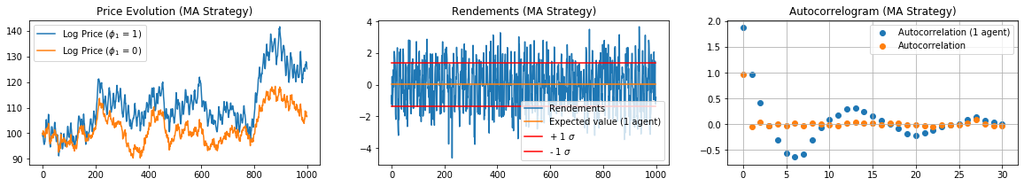

```python
#initialisations
phi_1 = 1
r_0 = np.random.normal()
k = 7

def sign(x):
    return int(x/abs(x))

def suivi_tendance_k(p_t,k):
    # On vérifie qu'on a assez de points pour pouvoir faire la moyenne mobile
    test = len(p_t) - k

    if test >=0: # On a assez de points
        MA_k = 0
        for i in range(len(p_t)-k,len(p_t)):
            MA_k += p_t[i] / k

        return sign(p_t[-1] - MA_k)

    else: # On n'a pas assez de points, mais on fait avec : on calcule une moyenne uniquement avec les points disponibles
        moy = 0
        for i in range(0,len(p_t)):
            moy += p_t[i]/len(p_t)
        return moy

#stratégie conditionnelle
p_t = [100]
p_t_sans_agent = [100]
r_t = [r_0]
r_t_variance, r_t_esperance = 0,r_0/NIT

time = list(range(NIT))
for t in range(1,NIT):
    w_1_t = phi_1 * suivi_tendance_k(r_t,k)
    r_t.append(epsilons[t] + w_1_t)
    p_t.append(p_t[-1] + r_t[-1])
    p_t_sans_agent.append(p_t_sans_agent[-1] + epsilons[t])

    r_t_esperance += r_t[-1]/NIT
    r_t_variance += (r_t[-1]**2)/NIT

r_t_variance -= r_t_esperance**2

autocorrelation_sans_agents = []
autocorrelation = []
for l in range(31):
    covariance_l_agents = 0
    covariance_l = 0
    r_t_esperance_sans_agent = 0

    for j in range(len(r_t)):
        r_t_esperance_sans_agent += epsilons[j]/len(r_t)

    for i in range(len(r_t)-l):
        covariance_l_agents += (r_t[i]-r_t_esperance)*(r_t[i+l]-r_t_esperance)/(len(r_t)-l)
        covariance_l += (epsilons[i]-r_t_esperance_sans_agent)*(epsilons[i+l]-r_t_esperance_sans_agent)/(len(r_t)-l)

    autocorrelation.append(covariance_l_agents)
    autocorrelation_sans_agents.append(covariance_l)

figure = plt.figure(figsize=(20,3))

ax1 = figure.add_subplot(131)
ax1.set_title("Price Evolution (MA Strategy)")
ax1.plot(time,p_t,label="Log Price ($\phi_1$ = " + str(phi_1) + ")")
ax1.plot(time,p_t_sans_agent,label="Log Price ($\phi_1$ = 0)")

plt.legend()

ax2 = figure.add_subplot(132)
ax2.plot(time, r_t, label="Rendements")
ax2.set_title('Rendements (MA Strategy)')
ax2.plot(time,[r_t_esperance]*len(time),label="Expected value (1 agent)")

ax2.plot(time,[r_t_esperance + np.sqrt(r_t_variance)]*len(time),label="+ 1 $\sigma$",color='r')
ax2.plot(time,[r_t_esperance - np.sqrt(r_t_variance)]*len(time),label="- 1 $\sigma$",color='r')

plt.legend()

ax3 = figure.add_subplot(133)
ax3.set_title("Autocorrelogram (MA Strategy)")
ax3.scatter(range(31),autocorrelation, label="Autocorrelation (1 agent)")
ax3.scatter(range(31),autocorrelation_sans_agents, label="Autocorrelation")

plt.legend()
plt.grid()
```

Observations :

- Les prix obtenus dans le cadre de la stratégie MA semblent suivre de manière assez semblable les variations des prix aléatoires (il faudrait cependant effectuer de nombreux tirages pour vérifier que ce comportement est significatif) ; il faut également remarquer que les rendements présentent des oscillations qui paraissent assez régulières en fonction du temps (période très faible, de l'ordre des quelques unités de temps).
- On constate que l'autocorrélation présent un comportement d'oscillateur amorti avec 1 agent alors qu'elle est presque nulle dès 1 pas dans le cas purement aléatoire : on peut affirmer que les rendements sont devenus nettement plus prévisibles (autocorrélation négligeable à partir d'un pas de 30 seulement).

## 3.4) Variance de $r$ en fonction de $\phi_1$

### Stratégie conditionnelle ($a_{1,t}=+sgn(r_t)$)

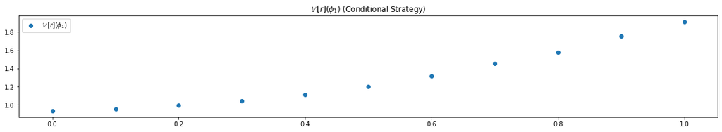

```python
phi_1_values = [0,0.1,0.2,0.3,0.4,0.5,0.6,0.7,0.8,0.9,1]
r_0 = np.random.normal()

def sign(x):
    return int(x/abs(x))

p_t = [[100],[100],[100],[100],[100],[100],[100],[100],[100],[100],[100]]
p_t_sans_agent = [[100],[100],[100],[100],[100],[100],[100],[100],[100],[100],[100]]
r_t = [[epsilons[0]],[r_0],[r_0],[r_0],[r_0],[r_0],[r_0],[r_0],[r_0],[r_0],[r_0]]
r_t_variance, r_t_esperance = [0]*11,[epsilons[0]/NIT] + [r_0/NIT]*10

for i,phi_1 in enumerate(phi_1_values):

    time = list(range(NIT))
    for t in range(1,NIT):
        w_1_t = phi_1 * sign(r_t[i][t-1])
        r_t[i].append(epsilons[t] + w_1_t)
        p_t[i].append(p_t[i][-1] + r_t[i][-1])

        r_t_esperance[i] += r_t[i][-1]/NIT
        r_t_variance[i] += (r_t[i][-1]**2)/NIT

    r_t_variance[i] -= r_t_esperance[i]**2

figure = plt.figure(figsize=(20,3))

ax1 = figure.add_subplot(111)
ax1.set_title("$\mathbb{V} \ [r](\phi_1)$ (Conditional Strategy)")
ax1.scatter(phi_1_values,r_t_variance,label="$\mathbb{V} \ [r](\phi_1)$")

plt.legend()
```

On remarque que la variance augmente suivant un comportement en $\propto \phi_1^2$ pour la stratégie conditionnelle : plus l'influence des agents est importante ($\phi_1$ est grand en valeur absolue) et plus les rendements présentent des variations disparates (logique car plus il y a de personnes sur un marché et plus on aura des outcomes différents) ; la volatilité augmente (la variance étant une mesure de la volatilité).

### Stratégie MA ($a_{1,t}=+sgn(p_t-MA_{k,t})$)

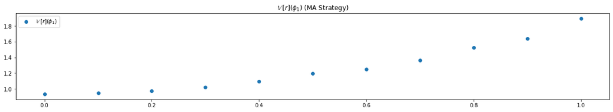

```python
phi_1_values = [0,0.1,0.2,0.3,0.4,0.5,0.6,0.7,0.8,0.9,1]
r_0 = np.random.normal()

def sign(x):
    return int(x/abs(x))

p_t = [[100],[100],[100],[100],[100],[100],[100],[100],[100],[100],[100]]
p_t_sans_agent = [[100],[100],[100],[100],[100],[100],[100],[100],[100],[100],[100]]
r_t = [[epsilons[0]],[r_0],[r_0],[r_0],[r_0],[r_0],[r_0],[r_0],[r_0],[r_0],[r_0]]
r_t_variance, r_t_esperance = [0]*11,[epsilons[0]/NIT] + [r_0/NIT]*10

for i,phi_1 in enumerate(phi_1_values):

    time = list(range(NIT))
    for t in range(1,NIT):
        w_1_t = phi_1 * suivi_tendance_k(r_t[i],k)
        r_t[i].append(epsilons[t] + w_1_t)
        p_t[i].append(p_t[i][-1] + r_t[i][-1])

        r_t_esperance[i] += r_t[i][-1]/NIT
        r_t_variance[i] += (r_t[i][-1]**2)/NIT

    r_t_variance[i] -= r_t_esperance[i]**2

figure = plt.figure(figsize=(20,3))

ax1 = figure.add_subplot(111)
ax1.set_title("$\mathbb{V} \ [r](\phi_1)$ (MA Strategy)")
ax1.scatter(phi_1_values,r_t_variance,label="$\mathbb{V} \ [r](\phi_1)$")

plt.legend()
```

On remarque que la variance augmente suivant un comportement en $\propto \phi_1^2$ pour la stratégie MA : plus l'influence des agents est importante ($\phi_1$ est grand en valeur absolue) et plus les rendements présentent des variations disparates (logique car plus il y a de personnes sur un marché et plus on aura des outcomes différents) ; la volatilité augmente (la variance étant une mesure de la volatilité).

## 3.5) Autocorrélation à 1 pas en fonction de $\phi_1$

### Stratégie conditionnelle ($a_{1,t}=+sgn(r_t)$)

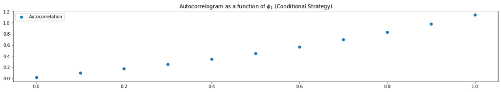

```python
phi_1_values = [0,0.1,0.2,0.3,0.4,0.5,0.6,0.7,0.8,0.9,1]
r_0 = np.random.normal()

def sign(x):
    return int(x/abs(x))

p_t = [[100],[100],[100],[100],[100],[100],[100],[100],[100],[100],[100]]
p_t_sans_agent = [[100],[100],[100],[100],[100],[100],[100],[100],[100],[100],[100]]
r_t = [[epsilons[0]],[r_0],[r_0],[r_0],[r_0],[r_0],[r_0],[r_0],[r_0],[r_0],[r_0]]
r_t_variance, r_t_esperance = [0]*11,[epsilons[0]/NIT] + [r_0/NIT]*10

for i,phi_1 in enumerate(phi_1_values):

    time = list(range(NIT))
    for t in range(1,NIT):
        w_1_t = phi_1 * sign(r_t[i][t-1])
        r_t[i].append(epsilons[t] + w_1_t)
        p_t[i].append(p_t[i][-1] + r_t[i][-1])

        r_t_esperance[i] += r_t[i][-1]/NIT
        r_t_variance[i] += (r_t[i][-1]**2)/NIT

    r_t_variance[i] -= r_t_esperance[i]**2

autocorrelations = []

for i,phi_1 in enumerate(phi_1_values):
    covariance_1_agents = 0

    for j in range(len(r_t[i])-1):
        covariance_1_agents += (r_t[i][j]-r_t_esperance[i])*(r_t[i][j+1]-r_t_esperance[i])/(len(r_t[i])-1)

    autocorrelations.append(covariance_1_agents)

figure = plt.figure(figsize=(20,3))

ax1 = figure.add_subplot(111)
ax1.set_title("Autocorrelogram as a function of $\phi_1$ (Conditional Strategy)")
ax1.scatter(phi_1_values,autocorrelations,label="Autocorrelation")

plt.legend()
```

### Stratégie MA ($a_{1,t}=+sgn(p_t-MA_{k,t})$)

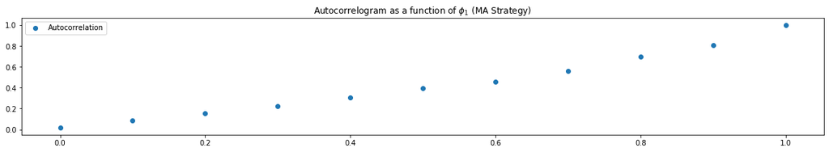

```python
phi_1_values = [0,0.1,0.2,0.3,0.4,0.5,0.6,0.7,0.8,0.9,1]
r_0 = np.random.normal()

def sign(x):
    return int(x/abs(x))

p_t = [[100],[100],[100],[100],[100],[100],[100],[100],[100],[100],[100]]
p_t_sans_agent = [[100],[100],[100],[100],[100],[100],[100],[100],[100],[100],[100]]
r_t = [[epsilons[0]],[r_0],[r_0],[r_0],[r_0],[r_0],[r_0],[r_0],[r_0],[r_0],[r_0]]
r_t_variance, r_t_esperance = [0]*11,[epsilons[0]/NIT] + [r_0/NIT]*10

for i,phi_1 in enumerate(phi_1_values):

    time = list(range(NIT))
    for t in range(1,NIT):
        w_1_t = phi_1 * suivi_tendance_k(r_t[i],k)
        r_t[i].append(epsilons[t] + w_1_t)
        p_t[i].append(p_t[i][-1] + r_t[i][-1])

        r_t_esperance[i] += r_t[i][-1]/NIT
        r_t_variance[i] += (r_t[i][-1]**2)/NIT

    r_t_variance[i] -= r_t_esperance[i]**2

autocorrelations = []

for i,phi_1 in enumerate(phi_1_values):
    covariance_1_agents = 0

    for j in range(len(r_t[i])-1):
        covariance_1_agents += (r_t[i][j]-r_t_esperance[i])*(r_t[i][j+1]-r_t_esperance[i])/(len(r_t[i])-1)

    autocorrelations.append(covariance_1_agents)

figure = plt.figure(figsize=(20,3))

ax1 = figure.add_subplot(111)
ax1.set_title("Autocorrelogram as a function of $\phi_1$ (MA Strategy)")
ax1.scatter(phi_1_values,autocorrelations,label="Autocorrelation")

plt.legend()
```

## 4) Plusieurs stratégies

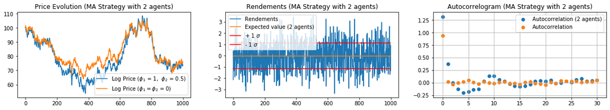

```python
#initialisations
phi_1 = 1
phi_2 = 0.5
r_0 = np.random.normal()
k_1 = 7
k_2 = 9

def sign(x):
    return int(x/abs(x))

def suivi_tendance_k(p_t,k):
    # On vérifie qu'on a assez de points pour pouvoir faire la moyenne mobile
    test = len(p_t) - k

    if test >=0: # On a assez de points
        MA_k = 0
        for i in range(len(p_t)-k,len(p_t)):
            MA_k += p_t[i] / k

        return sign(p_t[-1] - MA_k)

    else: # On n'a pas assez de points, mais on fait avec : on calcule une moyenne uniquement avec les points disponibles
        moy = 0
        for i in range(0,len(p_t)):
            moy += p_t[i]/len(p_t)
        return moy

#stratégie conditionnelle
p_t = [100]
p_t_sans_agent = [100]
r_t = [r_0]
r_t_variance, r_t_esperance = 0,r_0/NIT

time = list(range(NIT))
for t in range(1,NIT):
    w_1_t = phi_1 * suivi_tendance_k(r_t,k_1) - phi_2 * suivi_tendance_k(r_t,k_2)
    r_t.append(epsilons[t] + w_1_t)
    p_t.append(p_t[-1] + r_t[-1])
    p_t_sans_agent.append(p_t_sans_agent[-1] + epsilons[t])

    r_t_esperance += r_t[-1]/NIT
    r_t_variance += (r_t[-1]**2)/NIT

r_t_variance -= r_t_esperance**2

autocorrelation_sans_agents = []
autocorrelation = []
for l in range(31):
    covariance_l_agents = 0
    covariance_l = 0
    r_t_esperance_sans_agent = 0

    for j in range(len(r_t)):
        r_t_esperance_sans_agent += epsilons[j]/len(r_t)

    for i in range(len(r_t)-l):
        covariance_l_agents += (r_t[i]-r_t_esperance)*(r_t[i+l]-r_t_esperance)/(len(r_t)-l)
        covariance_l += (epsilons[i]-r_t_esperance_sans_agent)*(epsilons[i+l]-r_t_esperance_sans_agent)/(len(r_t)-l)

    autocorrelation.append(covariance_l_agents)
    autocorrelation_sans_agents.append(covariance_l)

figure = plt.figure(figsize=(20,3))

ax1 = figure.add_subplot(131)
ax1.set_title("Price Evolution (MA Strategy with 2 agents)")
ax1.plot(time,p_t,label="Log Price ($\phi_1$ = " + str(phi_1) + ", " + " $\phi_2$ = " + str(phi_2) +")")
ax1.plot(time,p_t_sans_agent,label="Log Price ($\phi_1 = \phi_2$ = 0)")

plt.legend()

ax2 = figure.add_subplot(132)
ax2.plot(time, r_t, label="Rendements")
ax2.set_title('Rendements (MA Strategy with 2 agents)')
ax2.plot(time,[r_t_esperance]*len(time),label="Expected value (2 agents)")

ax2.plot(time,[r_t_esperance + np.sqrt(r_t_variance)]*len(time),label="+ 1 $\sigma$",color='r')
ax2.plot(time,[r_t_esperance - np.sqrt(r_t_variance)]*len(time),label="- 1 $\sigma$",color='r')

plt.legend()

ax3 = figure.add_subplot(133)
ax3.set_title("Autocorrelogram (MA Strategy with 2 agents)")
ax3.scatter(range(31),autocorrelation, label="Autocorrelation (2 agents)")
ax3.scatter(range(31),autocorrelation_sans_agents, label="Autocorrelation")

plt.legend()
plt.grid()
```

## 4.1) Variance des rendements bidimensionnelle

### Stratégie MA ($a_{1,t}=+sgn(p_t-MA_{k,t})$)

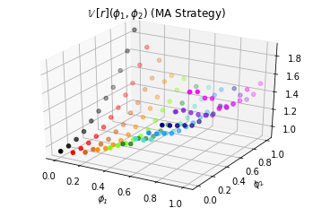

```python
from mpl_toolkits import mplot3d

fig = plt.figure()
ax = plt.axes(projection='3d')

phi_1_values = [0,0.1,0.2,0.3,0.4,0.5,0.6,0.7,0.8,0.9,1]
phi_2_values = [0,0.1,0.2,0.3,0.4,0.5,0.6,0.7,0.8,0.9,1]
r_0 = np.random.normal()

colors = ["black","red","chocolate","darkorange","lawngreen","forestgreen","turquoise","dodgerblue","navy","blueviolet","magenta"]

def sign(x):
    return int(x/abs(x))

p_t = []
p_t_sans_agent = []
r_t = []
r_t_variance = [0] * 11**2
r_t_esperance = ([epsilons[0]/NIT] + [r_0/NIT]*10)*11

for k in range(11**2):
    p_t.append([100])
    p_t_sans_agent.append([100])

    if k%11 == 0:
        r_t.append([epsilons[0]])
    else:
        r_t.append([r_0])

for i,phi_1 in enumerate(phi_1_values):
    for j,phi_2 in enumerate(phi_2_values):

        time = list(range(NIT))
        for t in range(1,NIT):
            w_1_t = phi_1 * suivi_tendance_k(r_t[11*i+j],k) - phi_2 * suivi_tendance_k(r_t[11*i+j],k_2)
            r_t[11*i+j].append(epsilons[t] + w_1_t)
            p_t[11*i+j].append(p_t[11*i+j][-1] + r_t[11*i+j][-1])

            r_t_esperance[11*i+j] += r_t[11*i+j][-1]/NIT
            r_t_variance[11*i+j] += (r_t[11*i+j][-1]**2)/NIT

        r_t_variance[11*i+j] -= r_t_esperance[11*i+j]**2

for i,phi_1 in enumerate(phi_1_values):
    X = []
    Y = []
    Z = []

    for j,phi_2 in enumerate(phi_2_values):
            X.append(phi_1)
            Y.append(phi_2)
            Z.append(r_t_variance[11*i+j])

    ax.scatter3D(X,Y,Z,c=colors[i])

ax.set_title("$\mathbb{V} \ [r](\phi_1, \phi_2)$ (MA Strategy)")
ax.set_xlabel("$\phi_1$")
ax.set_ylabel("$\phi_2$")
```

## 4.2) Autocorrélation à 1 pas en fonction de $(\phi_1,\phi_2)$

### Stratégie MA ($a_{1,t}=+sgn(p_t-MA_{k,t})$)

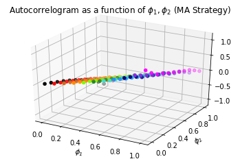

```python
phi_1_values = [0,0.1,0.2,0.3,0.4,0.5,0.6,0.7,0.8,0.9,1]
phi_2_values = [0,0.1,0.2,0.3,0.4,0.5,0.6,0.7,0.8,0.9,1]
r_0 = np.random.normal()

fig = plt.figure()
ax = plt.axes(projection='3d')

def sign(x):
    return int(x/abs(x))

p_t = []
p_t_sans_agent = []
r_t = []
r_t_variance = [0] * 11**2
r_t_esperance = ([epsilons[0]/NIT] + [r_0/NIT]*10)*11

for k in range(11**2):
    p_t.append([100])
    p_t_sans_agent.append([100])

    if k%11 == 0:
        r_t.append([epsilons[0]])
    else:
        r_t.append([r_0])

for i,phi_1 in enumerate(phi_1_values):
    for j,phi_2 in enumerate(phi_2_values):

        time = list(range(NIT))
        for t in range(1,NIT):
            w_1_t = phi_1 * suivi_tendance_k(r_t[11*i+j],k) - phi_2 * suivi_tendance_k(r_t[11*i+j],k_2)
            r_t[11*i+j].append(epsilons[t] + w_1_t)
            p_t[11*i+j].append(p_t[11*i+j][-1] + r_t[11*i+j][-1])

            r_t_esperance[11*i+j] += r_t[11*i+j][-1]/NIT
            r_t_variance[11*i+j] += (r_t[11*i+j][-1]**2)/NIT

        r_t_variance[11*i+j] -= r_t_esperance[11*i+j]**2

autocorrelations = []

for i,phi_1 in enumerate(phi_1_values):
    for a,phi_2 in enumerate(phi_2_values):
        covariance_1_agents = 0

        for j in range(len(r_t[11*i+a])-1):
            covariance_1_agents += (r_t[11*i+a][j]-r_t_esperance[11*i+a])*(r_t[11*i+a][j+1]-r_t_esperance[11*i+a])/(len(r_t[11*i+a])-1)

        autocorrelations.append(covariance_1_agents)

for i,phi_1 in enumerate(phi_1_values):
    X = []
    Y = []
    Z = []
    for j,phi_2 in enumerate(phi_2_values):
            X.append(phi_1)
            Y.append(phi_2)
            Z.append(autocorrelations[11*i+j])

    ax.scatter3D(X,Y,Z,c=colors[i])

ax.set_title("Autocorrelogram as a function of $\phi_1, \phi_2$ (MA Strategy)")
ax.set_xlabel("$\phi_1$")
ax.set_ylabel("$\phi_2$")
```